# **数据挖掘 第三次作业**

邓淇升** **16307110232** **大数据学院

25 Mar 2019

## **TASK 0**

在进行数据分析之前，先清空RStudio的命令行环境，以免历史数据产生影响：

```r
cat('\014')    ## 清空命令行窗口
```

然后清空RStudio工作区的全局变量：

```r
rm(list = ls())    ## 清空工作变量
```

## **TASK 1**

设置工作路径至文件所在文件夹：

```r
setwd("F:\\复旦大学\\课程课件\\新大二下学期\\1 数据挖掘\\Homework\\第3次作业")    ## 设置系统工作路径
```

从存有知乎用户数据的文件中读入数据集，命名为zhihu，查看数据集的分布情况。导入数据集前，需要将zhihu.csv文件的第一行第一列修改为“编号”。

```r
zhihu <- read.csv("zhihu.csv", stringsAsFactors = F)    ## 读入数据（需要修改zhihu.csv文件中第一行第一列为“编号”）
summary(zhihu)    ## 查看数据集的大致分布情况
```

```
##       编号           姓名                性别            回答数
##  Min.   :    5   Length:1918        Min.   :0.0000   Min.   :    1.0
##  1st Qu.: 3333   Class :character   1st Qu.:0.0000   1st Qu.:   21.0
##  Median : 7302   Mode  :character   Median :0.0000   Median :   64.0
##  Mean   : 7780                      Mean   :0.2096   Mean   :  209.7
##  3rd Qu.:11811                      3rd Qu.:0.0000   3rd Qu.:  183.0
##  Max.   :17518                      Max.   :2.0000   Max.   :16199.0
##      提问数            专栏数          分享数            点赞数
##  Min.   :   0.00   Min.   :0.000   Min.   :  0.000   Min.   :      1.0
##  1st Qu.:   0.00   1st Qu.:0.000   1st Qu.:  0.000   1st Qu.:    649.2
##  Median :   2.00   Median :1.000   Median :  0.000   Median :   3915.5
##  Mean   :  13.01   Mean   :0.804   Mean   :  4.647   Mean   :  25474.1
##  3rd Qu.:   7.00   3rd Qu.:1.000   3rd Qu.:  1.000   3rd Qu.:  18015.2
##  Max.   :1754.00   Max.   :8.000   Max.   :284.000   Max.   :1460757.0
##      感谢数           行业               公司               职业
##  Min.   :     1   Length:1918        Length:1918        Length:1918
##  1st Qu.:   128   Class :character   Class :character   Class :character
##  Median :   726   Mode  :character   Mode  :character   Mode  :character
##  Mean   :  4917
##  3rd Qu.:  3559
##  Max.   :250787
##    毕业院校             专业           是否备注公众号
##  Length:1918        Length:1918        Length:1918
##  Class :character   Class :character   Class :character
##  Mode  :character   Mode  :character   Mode  :character
##
##
##
##      关注数           被关注数
##  Min.   :    0.0   Min.   :     1
##  1st Qu.:   24.0   1st Qu.:   483
##  Median :   84.5   Median :  2240
##  Mean   :  237.4   Mean   : 16429
##  3rd Qu.:  217.2   3rd Qu.:  9360
##  Max.   :15837.0   Max.   :808142
```

在绘图之前保存好原始绘图格式，命名为opar：

```r
opar <- par(no.readonly = T)    ## 保存绘图原格式
```

## **TASK 2**

对数据集进行完初步的观察分析之后，决定采用“被关注数”作为因变量，并同时计算“对数被关注数”，使用直方图对“被关注数”和“对数被关注数”进行对比比较分析。

```r
zhihu$"对数被关注数" <- log(zhihu$"被关注数")    ## 计算对数被关注数
```

绘制“被关注数”和“对数被关注数”的直方图:

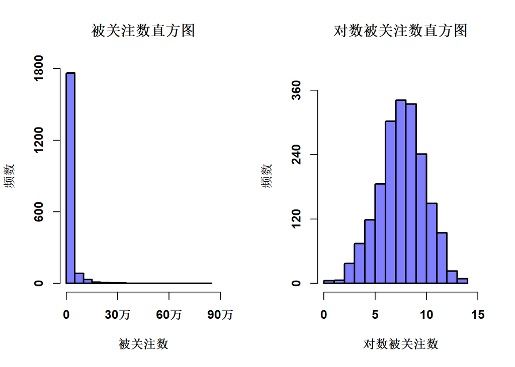

```r
par(mfrow = c(1, 2), font.main = 2, font.axis = 2, font.lab = 2, lwd = 2)    ## 设置绘图格式

hist(zhihu$"被关注数", freq = T, main = "被关注数直方图", col = "#7F7FFF", xlab = "被关注数", ylab = "频数", xlim = c(0, 900000), ylim = c(0, 1800), xaxt = "n", yaxt = "n")    ## 被关注数直方图
axis(1, at = seq(0, 900000, 300000), label = c("0", "30万", "60万", "90万"))    ## 设置x轴格式
axis(2, at = seq(0, 1800, 600))    ## 设置y轴格式

hist(zhihu$"对数被关注数", freq = T, main = "对数被关注数直方图", col = "#7F7FFF", xlab = "对数被关注数", ylab = "频数", xlim = c(0, 15), ylim = c(0, 400), xaxt = "n", yaxt = "n")    ## 对数被关注数直方图
axis(1, at = seq(0, 15, 5))    ## 设置x轴格式
axis(2, at = seq(0, 360, 120))    ## 设置y轴格式
```

```r
par(opar)    ## 格式复位
```

#### **分析解读**

作为本次分析研究的因变量，上图给出了“被关注数”和“对数被关注数”的分布情况。可以明显地观察到，“被关注数”并不符合正态分布，数据大多数聚集在5万以下，5万以上的被关注数相对来说非常的少。但“对数被关注数”则比较好地符合正态分布的特征，表明被关注数服从**对数正态分布**。

对数正态分布的特征是大多数数据聚集在相对“普通”的位置，相对“优秀”的数据非常少，相对“拙劣”的数据也比较少，但是因为“拙劣”程度最低也不能为负数，所以在数值上的分布就显示出对数正态的特征，即“普通”的数据众多但不出彩，但是“优秀”的数据非常出众且可以与“普通”的数据相差非常远，而“拙劣”的数据则比“普通”数据要差，但是不能突破零的界限。实际情况中，与此类似的现象还有人的智商分布、短跑时间分布和机械零件的可靠性分布等等。

在数据集的所有样本中，被关注数最多的知乎用户是毕业于北京第二外国语学院国际贸易专业的知乎联合创始人黄继新，被关注数为808142；被关注数最少的十个知乎用户的被关注数在8以下，均为点赞数、感谢数、分享数非常少的“小透明”用户，有可能是刚注册的用户或是对知乎不太感兴趣的用户。

## **TASK 3**

接下来对**分类型变量**进行描述性分析，分类型变量包括**所在公司**、**职业**和**毕业院校**。

### **所在公司**

首先用summary函数查看不同公司的出现次数，用head函数查看出现次数排名前20名的公司，排名为第20名的公司会出现部分省略的情况。

```r
head(summary(factor(zhihu$"公司")), n = 20)    ## 列出出现次数最多的前20个公司
```

```
##      阿里巴巴集团              腾讯              谷歌              百度
##                21                21                17                13
##              知乎          清华大学          Facebook        University
##                 9                 8                 6                 6
## 微软（Microsoft）       (University      ThoughtWorks          创业公司
##                 6                 5                 5                 5
##              网易          自由职业            NVIDIA          Research
##                 5                 5                 4                 4
##          北京大学            互联网        律师事务所            淘宝网
##                 4                 4                 4                 4
```

根据统计结果，阿里、腾讯、百度三巨头出现次数较多，将其合并命名为“BAT”，剩下的公司合并命名为“非BAT”。为保留原始的公司信息，在数据集zhihu的最后一列后面追加一列作为新的公司分类，命名为“company”。命名时首先把三巨头标记为“BAT”，在变量company中，未标记为“BAT”的数据为空值NA，故直接对标记为NA的company数据命名为“非BAT”。

```r
zhihu$company[zhihu$"公司" == "阿里巴巴集团" | zhihu$"公司" == "腾讯" | zhihu$"公司" == "百度"] <- "BAT"    ## 标记为BAT
zhihu$company[is.na(zhihu$company)] <- "非BAT"    ## 未标记为BAT的数据标记为非BAT
zhihu$company <- factor(zhihu$company, c("BAT", "非BAT"))    ## 调整因子排序
```

绘制“对数被关注数”关于**所在公司**“company”的箱线图：

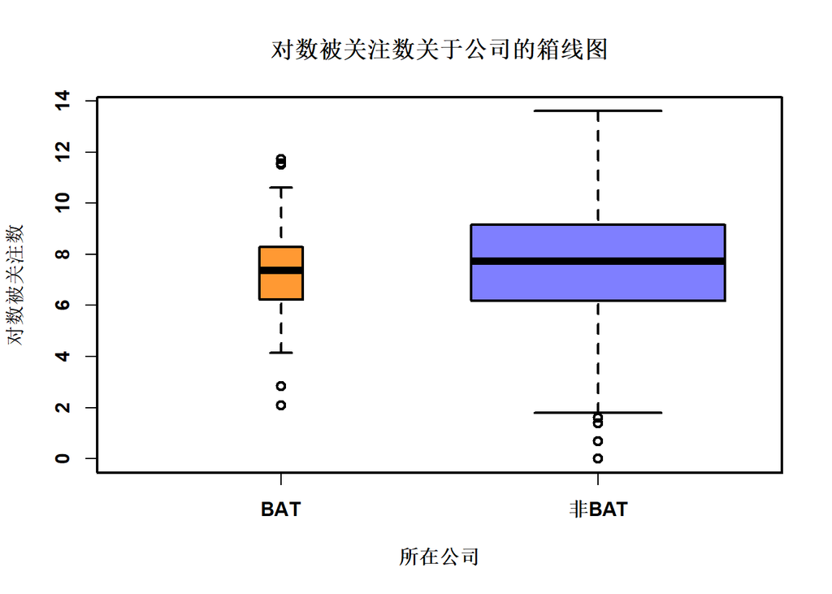

```r
par(font.main = 2, font.axis = 2, font.lab = 2, lwd = 2, pch = 1)    ## 设置绘图格式

boxplot(zhihu$"对数被关注数" ~ zhihu$company, main = "对数被关注数关于公司的箱线图", xlab = "所在公司", ylab = "对数被关注数", col = c("#FF9933", "#7F7FFF"), varwidth = T, names = c("BAT", "非BAT"))    ## 所在公司的箱线图
```

```r
par(opar)    ## 格式复位
```

#### **分析解读**

在关于公司的箱线图中，两个箱子的大小反映了知乎用户所在公司的数量比例，属于BAT的箱子相对非常的窄，这是因为所有知乎用户当中，所在公司为BAT的用户非常的少。观察箱线图发现，两个箱子的高度相近，平均值和分位数相差不大，表明单从描述性分析来说，**是否进入BAT对知乎用户的被关注数影响不太大，即公司知名度不一定能有效增加被关注数**。

### **职业**

与所在公司的分析相同，用summary函数和head函数查看出现次数排名前20名的职业，排名为第20名的职业同样会出现部分省略的情况。可以发现在“职业”变量中创始人的出现次数最多。

```r
head(summary(factor(zhihu$"职业")), n = 20)    ## 列出出现次数最多的前20个职业
```

```
##      创始人         CEO  联合创始人    产品经理          of    (Google)
##         101          61          26          22          19          17
##      合伙人  前端工程师    产品总监      工程师         CTO    Software
##          15          15          12          12          11          11
##     Founder        打杂 (University    Research        博士  软件工程师
##          10          10           9           9           9           9
##  博士生在读        记者
##           8           8
```

根据统计结果，将“职业”变量中的创始人、联合创始人、CEO、合伙人统一划分为“创始人”，剩余的划分为“非创始人”。同样，为保留原始的职业信息，在数据集zhihu的最后一列后面追加一列作为新的职业分类，命名为“occupation”。命名方法同上，首先对创始人和CEO等数据标记为“创始人”，在变量occupation中，未标记为“创始人”的数据为空值NA，直接对标记为NA的occupation数据命名为“非创始人”。

```r
zhihu$occupation[zhihu$"职业" == "创始人" | zhihu$"职业" == "CEO" | zhihu$"职业" == "联合创始人" | zhihu$"职业" == "合伙人"] <- "创始人"    ## 标记为创始人
zhihu$occupation[is.na(zhihu$occupation)] <- "非创始人"    ## 未标记为创始人的数据标记为非创始人
zhihu$occupation <- factor(zhihu$occupation, c("创始人", "非创始人"))    ## 调整因子排序
```

绘制“对数被关注数”关于**职业**“occupation”的箱线图：

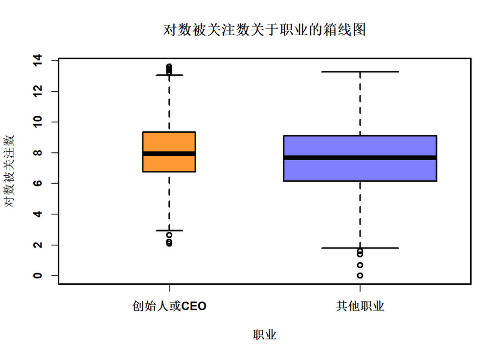

```r
par(font.main = 2, font.axis = 2, font.lab = 2, lwd = 2, pch = 1)    ## 设置绘图格式

boxplot(zhihu$"对数被关注数" ~ zhihu$occupation, main = "对数被关注数关于职业的箱线图", xlab = "职业", ylab = "对数被关注数", col = c("#FF9933", "#7F7FFF"), varwidth = T, names = c("创始人或CEO", "其他职业"))    ## 职业的箱线图
```

```r
par(opar)    ## 格式复位
```

#### **分析解读**

在关于职业的箱线图中，同样可以发现作为创始人或CEO的“企业老板”数量相对较少。但是两个箱子的高度也相近，“创始人”的平均值和分位数整体稍微比“非创始人”要高一点，但整体还是较为接近。表明作为创始人，其知乎用户会相对来说会更加“吸粉”，但是两者差异程度并没有太大，即**无论是行业的领头精英还是行业的螺丝钉，都有自己的被关注量**。

### **毕业院校**

与前面的分析相同，用summary函数和head函数查看出现次数排名前20名的毕业院校，排名为第20名的毕业院校同样会出现部分省略的情况。可以发现国内排名靠前的大学出现次数较多。

```r
head(summary(factor(zhihu$"毕业院校")), n = 20)    ## 列出出现次数最多的前20个毕业院校
```

```
##            北京大学            清华大学            浙江大学
##                  65                  63                  42
##            复旦大学          University        上海交通大学
##                  37                  34                  26
##            南京大学        华中科技大学            同济大学
##                  21                  17                  17
##            武汉大学        中国传媒大学    中山大学（SYSU）
##                  17                  16                  16
##        北京师范大学        哥伦比亚大学        中国人民大学
##                  15                  15                  15
##    北京航空航天大学 北京理工大学（BIT）            南开大学
##                  14                  13                  13
##        电子科技大学      卡内基梅隆大学
##                  12                  12
```

根据统计结果，将“毕业院校”划分为“清北复交浙”和“非清北复交浙”。同样，为保留原始的毕业院校信息，在数据集zhihu的最后一列后面追加一列作为新的毕业院校分类，命名为“graduate”。命名方法同上，首先对“毕业院校”为清北复交浙的数据进行标记，在变量graduate中，未标记为“清北复交浙”的数据为空值NA，直接对标记为NA的graduate数据命名为“非清北复交浙”。

```r
zhihu$graduate[zhihu$"毕业院校" == "北京大学" | zhihu$"毕业院校" == "清华大学" | zhihu$"毕业院校" == "复旦大学" | zhihu$"毕业院校" == "上海交通大学" | zhihu$"毕业院校" == "浙江大学"] <- "清北复交浙"    ## 标记为清北复交浙
zhihu$graduate[is.na(zhihu$graduate)] <- "非清北复交浙"    ## 未标记为清北复交浙的数据标记为非清北复交浙
zhihu$graduate <- factor(zhihu$graduate, c("清北复交浙", "非清北复交浙"))    ## 调整因子排序
```

绘制“对数被关注数”关于**毕业院校**“graduate”的箱线图：

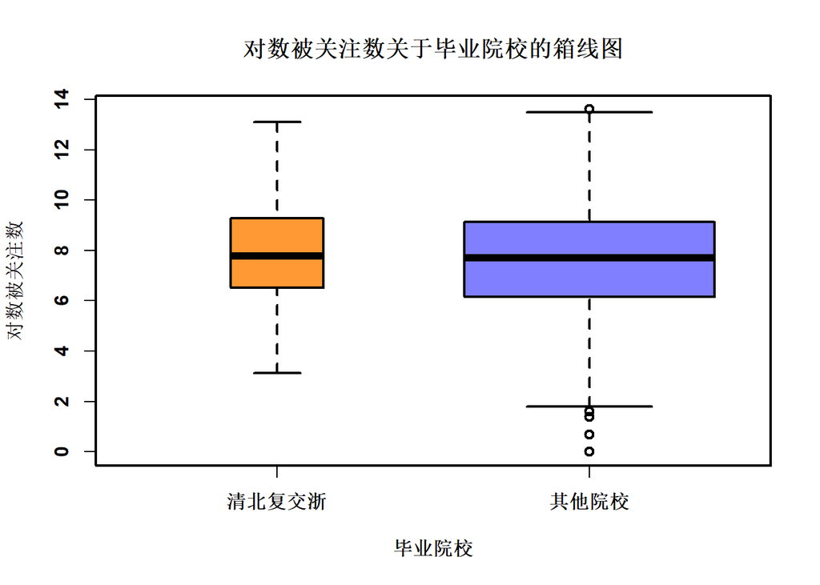

```r
par(font.main = 2, font.axis = 2, font.lab = 2, lwd = 2, pch = 1)    ## 设置绘图格式

boxplot(zhihu$"对数被关注数" ~ zhihu$graduate, main = "对数被关注数关于毕业院校的箱线图", xlab = "毕业院校", ylab = "对数被关注数", col = c("#FF9933", "#7F7FFF"), varwidth = T, names = c("清北复交浙", "其他院校"))    ## 毕业院校的箱线图
```

```r
par(opar)    ## 格式复位
```

#### **分析解读**

在关于毕业院校的分析中，可以发现来自清北复交浙的毕业生相对少很多，毕竟学校总数相差太远，人数也会有一定差异。观察两个箱子，发现差异程度比公司和职业更少，平均值和分位数基本平齐，表明**毕业院校对知乎用户的被关注数影响不大**，无论是出身TOP5还是普通高校，知乎的被关注量表面上与学识是否渊博无关。

综合上述三点分析，可以看出，更好的公司、职业和毕业院校并不能大幅提升知乎用户的被关注数，从整体上说，日常生活中更优秀的用户获得的被关注数的可能性相对会较高，但差异真的不大。表明**想成为知乎大V并不一定需要进BAT、考上清北复交浙以及当上大老板**。

## **TASK 4**

然后是对**连续型变量**进行描述性分析，连续型变量包括**提问数**、**点赞比**、**感谢比**和**分享比**。

首先对“提问数”进行分析，使用summary函数查看“提问数”的分布情况，发现其四分之三分位点为7，故以此为界限进行离散化处理，将提问数小于7次的数据标记为“低问”，将提问数大于等于7次的数据标记为“高问”。命名方法与分类型变量类似，需要使用到is.na函数并且追加一列变量命名为“question”。

```r
summary(zhihu$"提问数")    ## 查看提问数的分布情况
```

```
##    Min. 1st Qu.  Median    Mean 3rd Qu.    Max.
##    0.00    0.00    2.00   13.01    7.00 1754.00
```

```r
zhihu$question[zhihu$"提问数" >= 7.00] <- "高问"    ## 标记为高问
zhihu$question[is.na(zhihu$question)] <- "低问"    ## 未标记为高问的数据标记为低问
zhihu$question <- factor(zhihu$question, c("高问", "低问"))    ## 调整因子排序
```

对连续型数据进行完离散化处理之后，绘制“对数被关注数”关于**提问数**“question”的箱线图：

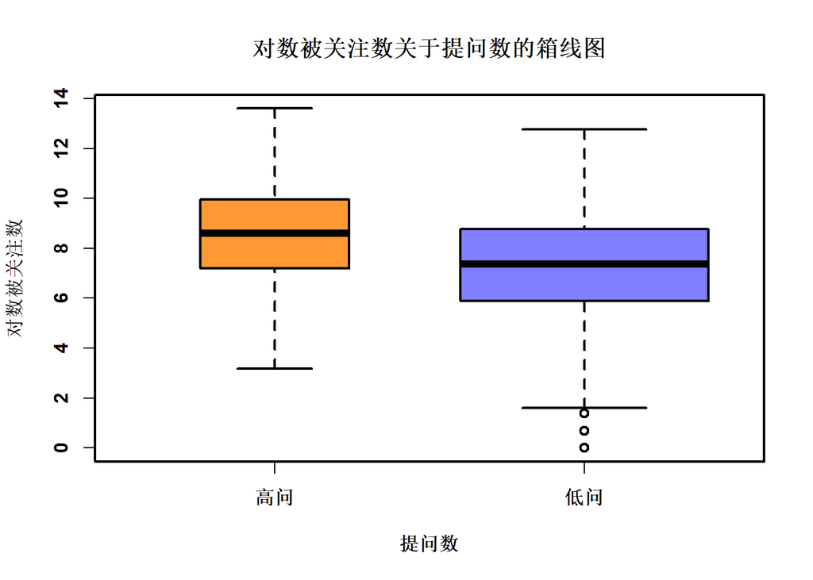

```r
par(font.main = 2, font.axis = 2, font.lab = 2, lwd = 2, pch = 1)    ## 设置绘图格式

boxplot(zhihu$"对数被关注数" ~ zhihu$question, main = "对数被关注数关于提问数的箱线图", xlab = "提问数", ylab = "对数被关注数", col = c("#FF9933", "#7F7FFF"), varwidth = T, names = c("高问", "低问"))    ## 提问数的箱线图
```

```r
par(opar)    ## 格式复位
```

#### **分析解读**

与分类型变量类似，在对连续型变量进行完离散化处理之后，可以得到比较明显的结论。在关于提问数的箱线图中，可以明显地观察到，“高提问数”的被关注数整体明显比“低关注数”的被关注数要高，平均值和分位数相应都超出了一个单位。表明提问数是影响被关注数的比较重要的一个因素，即**提问的数量越多，被关注的可能性越大，获得的被关注量也就越多**。

## **TASK 5**

除了像任务四中直接对现有的**连续型变量**进行描述性分析之外，还可以使用现有的数据构造衍生自变量，例如**点赞回答比**、**感谢回答比**和**分享回答比**，这三个变量分别是由“点赞数”、“感谢数”、“分享数”除以“回答数”获得的。

### **点赞回答比**

```r
zhihu$"点赞比"[zhihu$"点赞数" / zhihu$"回答数" > 100] <- "高"    ## 点赞比大于100的标记为高点赞比
zhihu$"点赞比"[zhihu$"点赞数" / zhihu$"回答数" <= 100] <- "低"    ## 点赞比小于等于100的标记为低点赞比
zhihu$"点赞比" <- factor(zhihu$"点赞比", c("高", "低"))    ## 调整因子排序

summary(factor(zhihu$"点赞比"))    ## 统计点赞比情况
```

```
##   高   低
##  700 1218
```

对点赞比进行完高低水平的划分之后，绘制“对数被关注数”关于**“点赞比”**的箱线图：

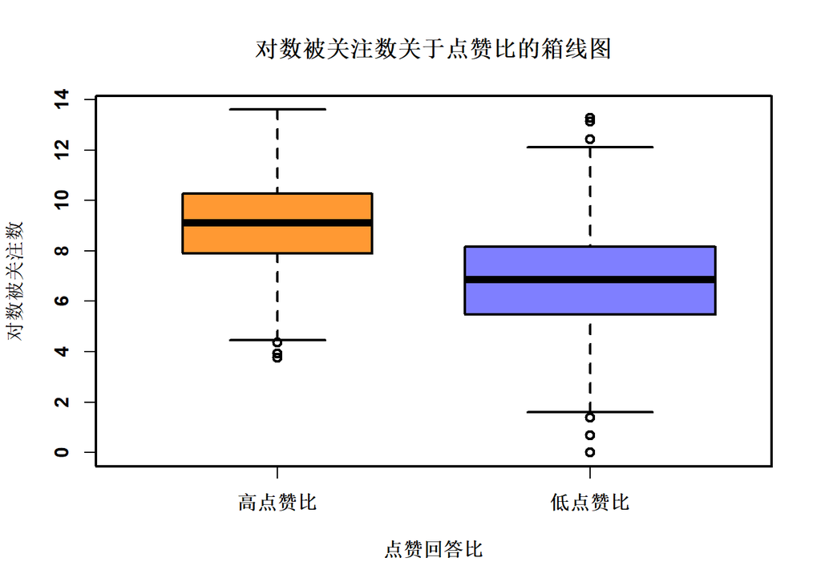

```r
par(font.main = 2, font.axis = 2, font.lab = 2, lwd = 2, pch = 1)    ## 设置绘图格式

boxplot(zhihu$"对数被关注数" ~ zhihu$"点赞比", main = "对数被关注数关于点赞比的箱线图", xlab = "点赞回答比", ylab = "对数被关注数", col = c("#FF9933", "#7F7FFF"), varwidth = T, names = c("高点赞比", "低点赞比"))    ## 点赞回答比的箱线图
```

```r
par(opar)    ## 格式复位
```

### **感谢回答比**

其次对“感谢回答比”进行分析，在计算感谢回答比时按照10为界限直接将感谢回答比划分为“高感谢比”和“低感谢比”，结果是追加一列变量命名为“感谢比”至数据集末尾。使用summary函数查看“感谢比”的分布情况。

```r
zhihu$"感谢比"[zhihu$"感谢数" / zhihu$"回答数" > 10] <- "高"    ## 感谢比大于10的标记为高感谢比
zhihu$"感谢比"[zhihu$"感谢数" / zhihu$"回答数" <= 10] <- "低"    ## 感谢比小于等于10的标记为低感谢比
zhihu$"感谢比" <- factor(zhihu$'感谢比', c("高", "低"))    ## 调整因子排序

summary(factor(zhihu$"感谢比"))    ## 统计感谢比情况
```

```
##  高  低
## 958 960
```

对感谢比进行完高低水平的划分之后，绘制“对数被关注数”关于**“感谢比”**的箱线图：

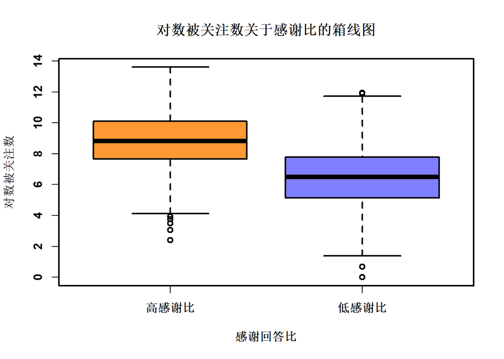

```r
par(font.main = 2, font.axis = 2, font.lab = 2, lwd = 2, pch = 1)    ## 设置绘图格式

boxplot(zhihu$"对数被关注数" ~ zhihu$"感谢比", main = "对数被关注数关于感谢比的箱线图", xlab = "感谢回答比", ylab = "对数被关注数", col = c("#FF9933", "#7F7FFF"), varwidth = T, names = c("高感谢比", "低感谢比"))    ## 感谢回答比的箱线图
```

```r
par(opar)    ## 格式复位
```

### **分享回答比**

然后对“分享回答比”进行分析，在计算分享回答比时按照0为界限直接将分享回答比划分为“高分享比”和“低分享比”，此处的划分较前两个变量有所不同，“低分享比”指的是分享数为0的数据，结果同样是追加一列变量命名为“分享比”至数据集末尾。使用summary函数查看“分享比”的分布情况。

```r
zhihu$"分享比"[zhihu$"分享数" / zhihu$"回答数" > 0] <- "高"    ## 分享比大于0的标记为高分享比
zhihu$"分享比"[zhihu$"分享数" / zhihu$"回答数" <= 0] <- "低"    ## 分享比为0的标记为低分享比
zhihu$"分享比" <- factor(zhihu$"分享比", c("高", "低"))    ## 调整因子排序

summary(factor(zhihu$"分享比"))    ## 统计分享比情况
```

```
##   高   低
##  628 1290
```

对分享比进行完高低水平的划分之后，绘制“对数被关注数”关于**“分享比”**的箱线图：

[figure not shown]

```r
par(font.main = 2, font.axis = 2, font.lab = 2, lwd = 2, pch = 1)    ## 设置绘图格式

boxplot(zhihu$对数被关注数 ~ zhihu$点赞比, main = "对数被关注数关于分享比的箱线图", xlab = "分享回答比", ylab = "对数被关注数", col = c("#FF9933", "#7F7FFF"), varwidth = T, names = c("高分享比", "低分享比"))    ## 分享回答比的箱线图
```

```r
par(opar)    ## 格式复位
```

## **TASK 6**

对分类型变量和连续型变量进行完描述性分析之后可对数据集zhihu进行线性回归分析，同样选择采用“对数被关注数”作为因变量。首先抽取数据集中有关的列用于建立线性回归模型，将新的子数据集命名为lm.zhihu，并适当修改列名。

```r
lm.zhihu <- zhihu[c("编号", "姓名", "性别", "被关注数", "company", "occupation", "graduate", "回答数", "提问数", "专栏数", "点赞比", "感谢比", "分享比", "对数被关注数")]    ## 提取有关数据进行线性回归

names(lm.zhihu)[5:7] <- c("公司", "职业", "毕业院校")    ## 将英文变量名称修改为中文
```

分别计算点赞回答比、感谢回答比和分享回答比，用于与对数被关注数进行散点图分析：

```r
lm.zhihu$"点赞回答比" <- zhihu$"点赞数" / zhihu$"回答数"
lm.zhihu$"感谢回答比" <- zhihu$"感谢数" / zhihu$"回答数"
lm.zhihu$"分享回答比" <- zhihu$"分享数" / zhihu$"回答数"
```

挑选数据集中的数值型数据与因变量“对数被关注数”，绘制散点图矩阵，观察数值型数据之间的关系特征：

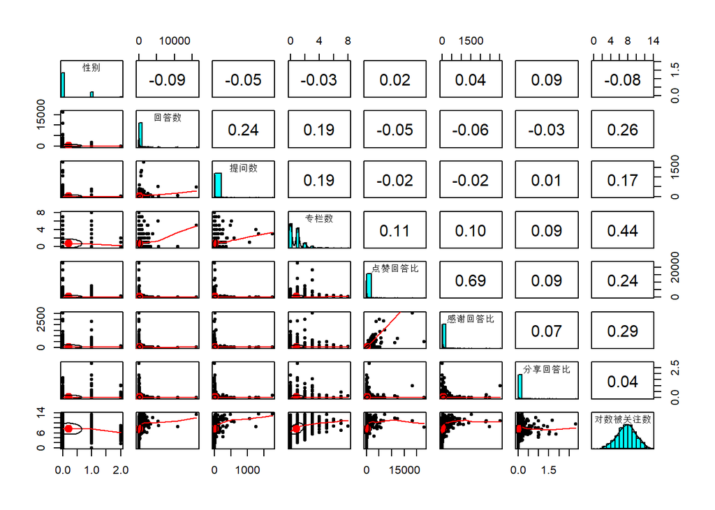

```r
library(psych)    ## 载入数据特征可视化的psych包
pairs.panels(lm.zhihu[c(3, 8, 9, 10, 15, 16, 17, 14)])    ## 查看散点图矩阵
```

```r
model.zhihu <- lm(log(被关注数) ~ 性别 + 公司 + 职业 + 毕业院校 + 回答数 + 提问数 + 专栏数 + 点赞比 + 感谢比 + 分享比, lm.zhihu)    ## 进行多元线性回归

summary(model.zhihu)    ## 查看线性回归分析
```

```
##
## Call:
## lm(formula = log(被关注数) ~ 性别 + 公司 + 职业 + 毕业院校 +
##     回答数 + 提问数 + 专栏数 + 点赞比 + 感谢比 + 分享比, data = lm.zhihu)
##
## Residuals:
##      Min       1Q   Median       3Q      Max
## -10.1315  -0.9395   0.0555   1.0194   5.3865
##
## Coefficients:
##                        Estimate Std. Error t value Pr(>|t|)
## (Intercept)           9.352e+00  2.729e-01  34.273  < 2e-16 ***
## 性别                 -2.983e-01  8.012e-02  -3.724 0.000202 ***
## 公司非BAT             1.785e-01  2.138e-01   0.835 0.404031
## 职业非创始人         -2.604e-01  1.164e-01  -2.236 0.025473 *
## 毕业院校非清北复交浙 -3.848e-01  1.090e-01  -3.530 0.000426 ***
## 回答数                7.878e-04  6.298e-05  12.509  < 2e-16 ***
## 提问数                1.491e-03  5.166e-04   2.886 0.003952 **
## 专栏数                5.358e-01  3.815e-02  14.044  < 2e-16 ***
## 点赞比低             -9.554e-01  9.954e-02  -9.598  < 2e-16 ***
## 感谢比低             -1.611e+00  9.473e-02 -17.009  < 2e-16 ***
## 分享比低             -6.866e-01  7.981e-02  -8.604  < 2e-16 ***
## ---
## Signif. codes:  0 '***' 0.001 '**' 0.01 '*' 0.05 '.' 0.1 ' ' 1
##
## Residual standard error: 1.555 on 1907 degrees of freedom
## Multiple R-squared:  0.519,  Adjusted R-squared:  0.5165
## F-statistic: 205.8 on 10 and 1907 DF,  p-value: < 2.2e-16
```

使用anova函数查看回归方差分析：

```r
anova(model.zhihu)    ## 查看方差分析
```

```
## Analysis of Variance Table
##
## Response: log(被关注数)
##             Df Sum Sq Mean Sq F value    Pr(>F)
## 性别         1   58.7   58.75  24.282 9.040e-07 ***
## 公司         1   10.5   10.46   4.324  0.037711 *
## 职业         1   25.8   25.80  10.662  0.001113 **
## 毕业院校     1    9.7    9.69   4.007  0.045452 *
## 回答数       1  612.7  612.74 253.262 < 2.2e-16 ***
## 提问数       1  117.6  117.64  48.623 4.261e-12 ***
## 专栏数       1 1411.4 1411.38 583.359 < 2.2e-16 ***
## 点赞比       1 1826.3 1826.31 754.859 < 2.2e-16 ***
## 感谢比       1  726.3  726.33 300.210 < 2.2e-16 ***
## 分享比       1  179.1  179.09  74.021 < 2.2e-16 ***
## Residuals 1907 4613.8    2.42
## ---
## Signif. codes:  0 '***' 0.001 '**' 0.01 '*' 0.05 '.' 0.1 ' ' 1
```

除此之外，还需要探究是否存在多重共线性的情况，使用corrplot函数和vif函数两种方法检验多重共线性。

计算协方差矩阵，使用corrplot函数对变量之间的相关性进行可视化处理，按图中的颜色表示，颜色越接近深蓝色表明共线性程度越大：

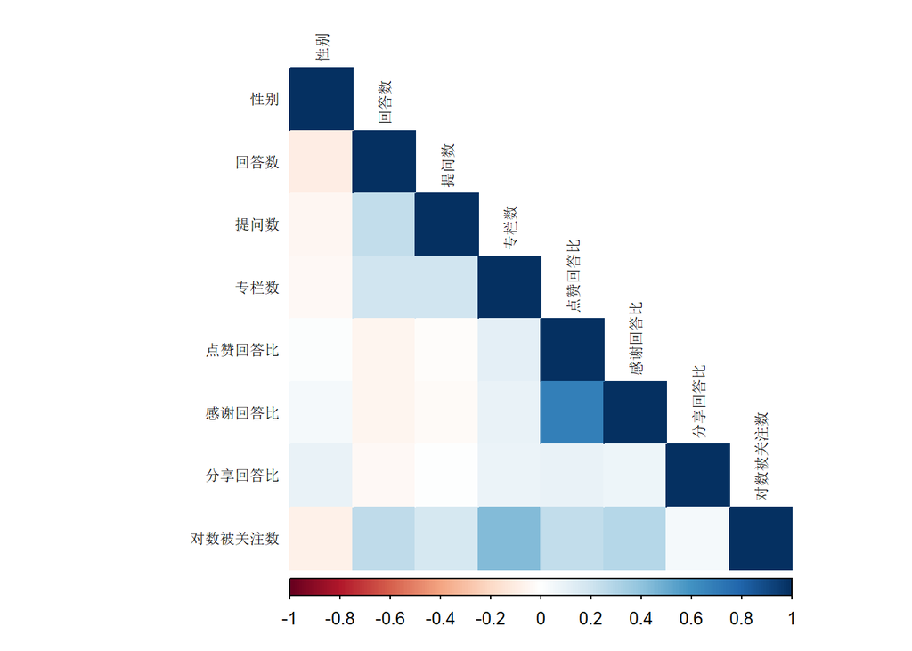

```r
corMatrix <- cor(lm.zhihu[c("性别", "回答数", "提问数", "专栏数", "点赞回答比", "感谢回答比", "分享回答比", "对数被关注数")])    ## 计算协方差矩阵

library(corrplot)    ## 载入方差可视化的corrplot包
corrplot(corMatrix, order = "original", method = "color", type = "lower", tl.cex = 0.7, tl.col = rgb(0,0,0))    ## 识别并检验多重共线性
```

使用vif函数计算方差膨胀因子，经验上vif大于4或大于10以上时表明变量之间存在共线性：

```r
library(car)    ## 载入回归诊断的car包
vif(model.zhihu)    ## 查看方差膨胀因子以检验多重共线性
```

```
##     性别     公司     职业 毕业院校   回答数   提问数   专栏数   点赞比
## 1.018188 1.009633 1.017239 1.005523 1.122738 1.094620 1.190224 1.820485
##   感谢比   分享比
## 1.778661 1.111895
```

最后用模型诊断图对数据集zhihu的多元线性回归模型进行分析解读：

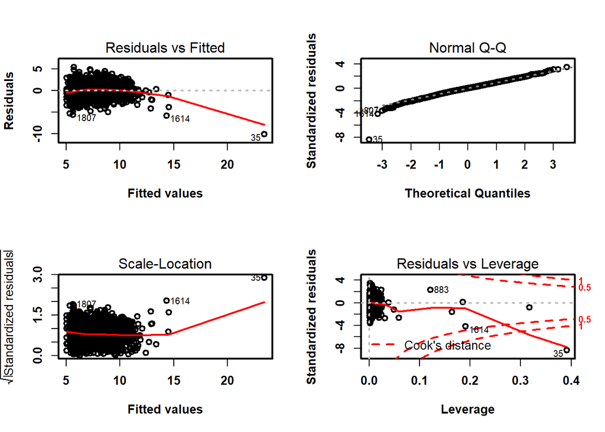

```r
par(mfrow = c(2, 2), font.main = 2, font.axis = 2, font.lab = 2, lwd = 2, pch = 1)    ## 设置绘图格式

plot(model.zhihu)    ## 查看模型诊断图
```

```r
par(opar)    ## 格式复位
```

#### **分析解读**

首先对散点图矩阵进行分析，散点图矩阵将性别、回答数、提问数、专栏数、点赞比、感谢比、分享比等自变量与对数被关注数这个因变量放在一起进行交互性分析。其中已经由前面分析得到的重要影响因素点赞比、感谢比、分享比和提问数也在其中，可以观察这些变量关于对数被关注数的散点图和r值，很明显不成线性关系，但是整体趋势是正相关的，这说明需要进一步的回归分析。